# homework 6

Italo Carvalho Vianelli Ribeiro

09/07/2020

Homework 6

RA 769687

```r
library(dplyr)
```

```r
library(tidyr)
library(ggplot2)
library(readxl)
library(patchwork)
library(scales)
library(gridExtra)
corona = read_excel("HIST_PAINEL_COVIDBR_15jun2020.xlsx",
                                            col_types = c("text",    # Regiao
                                                          "text",    # Estado
                                                          "text",    # Municipio
                                                          "text",    # coduf
                                                          "numeric", # codmun
                                                          "numeric", # codRegiaoSaude
                                                          "text",    # nomeRegiaoSaude
                                                          "date",    # data
                                                          "numeric", # semanaEpi
                                                          "text",    # populacaoTCU2019
                                                          "numeric", # casosAcumulado
                                                          "numeric", # casosNovos
                                                          "numeric", # obitosAcumulado
                                                          "numeric", # obitosNovos
                                                          "numeric", # Recuperadosnovos
                                                          "numeric"  # emAcompanhamentoNovos
                                                          ))

head(corona)
```

```
## # A tibble: 6 x 16
##   regiao estado municipio coduf codmun codRegiaoSaude nomeRegiaoSaude
##   <chr>  <chr>  <chr>     <chr>  <dbl>          <dbl> <chr>
## 1 Brasil <NA>   <NA>      76        NA             NA <NA>
## 2 Brasil <NA>   <NA>      76        NA             NA <NA>
## 3 Brasil <NA>   <NA>      76        NA             NA <NA>
## 4 Brasil <NA>   <NA>      76        NA             NA <NA>
## 5 Brasil <NA>   <NA>      76        NA             NA <NA>
## 6 Brasil <NA>   <NA>      76        NA             NA <NA>
## # ... with 9 more variables: data <dttm>, semanaEpi <dbl>,
## #   populacaoTCU2019 <chr>, casosAcumulado <dbl>, casosNovos <dbl>,
## #   obitosAcumulado <dbl>, obitosNovos <dbl>, Recuperadosnovos <dbl>,
## #   emAcompanhamentoNovos <dbl>
```

Primeiro eu quis fazer a analise de casos acumulados por região do Brasil. E pude analisar que até junho, sudeste e o nordeste são os estados que possuem o maior numeros de casos de COVID-19 acumulados até então

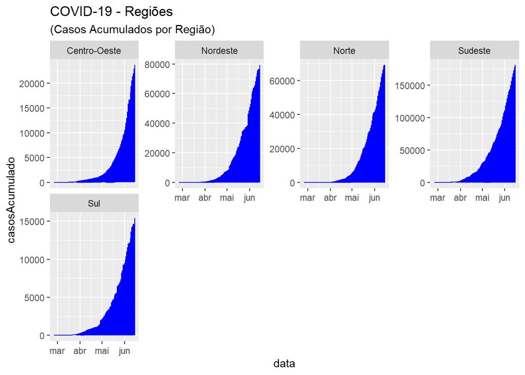

```r
coronaregiao=filter(corona, !is.na(corona$estado)& is.na(corona$municipio))
ggplot(coronaregiao, aes(data, casosAcumulado)) +
  geom_line(color="blue") +
  facet_wrap(vars(regiao), ncol = 4, scales = "free_y")+
  labs(
    title = "COVID-19 - Regiões",
    subtitle = "(Casos Acumulados por Região)"
    )
```

Esses dados de casos se refletem no número de óbitos acumulados por cada região com as regiões sudeste e nordeste com os maiores números de óbitos

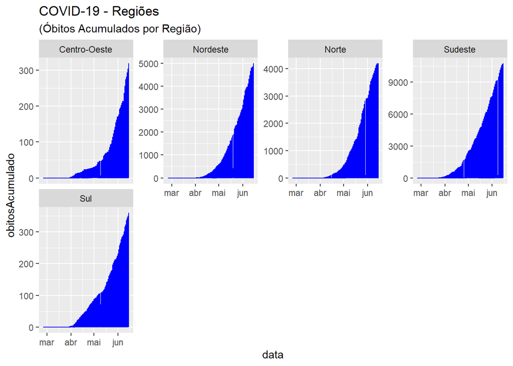

```r
coronaregiao=filter(corona, !is.na(corona$estado)& is.na(corona$municipio))
ggplot(coronaregiao, aes(data, obitosAcumulado)) +
  geom_line(color="blue") +
  facet_wrap(vars(regiao), ncol = 4, scales = "free_y")+
  labs(
    title = "COVID-19 - Regiões",
    subtitle = "(Óbitos Acumulados por Região)"
    )
```

Após analisar as regiões resolvi analisar os novos casos de COVID-19 no município que eu moro que é Campinas - SP, e pude perceber que de março a junho, os casos vem aumentando

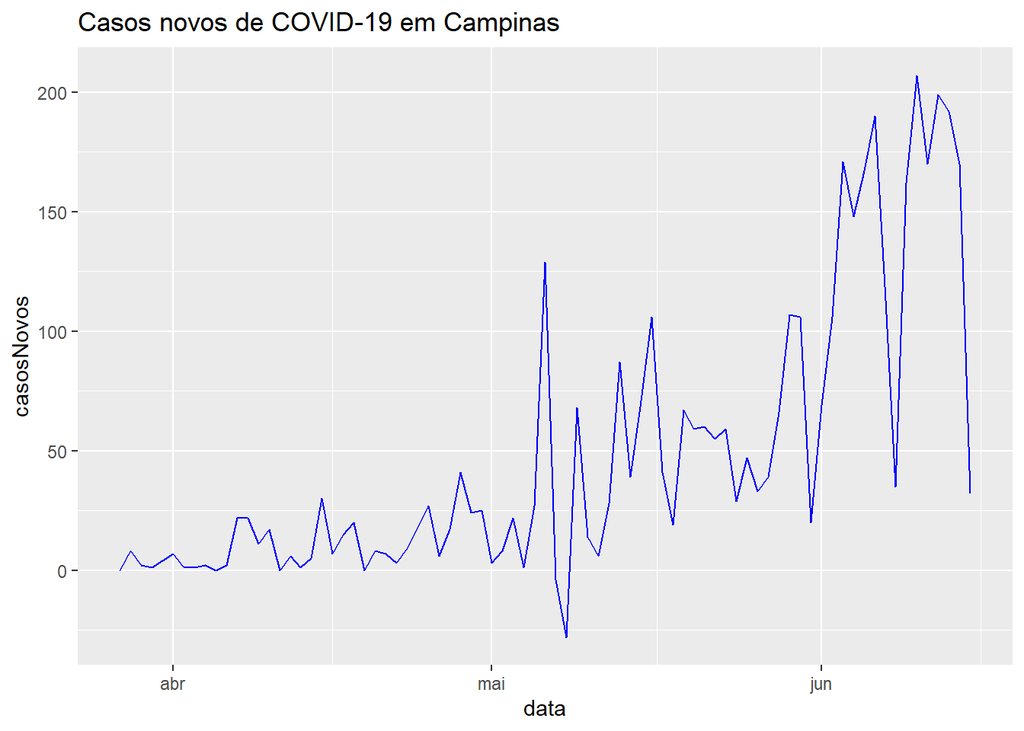

```r
municípios=municipios <- corona %>%
  filter(!is.na(estado), !is.na(municipio))
Campinas=municipios <- corona %>%
  filter(!is.na(estado), !is.na(municipio), municipio=="Campinas")
newcasescps=ggplot(Campinas, aes(x = data, y = casosNovos)) +
  geom_line(color="blue")
newcasescps + labs(title="Casos novos de COVID-19 em Campinas")
```

sequencialmente, avaliei os óbitos tanto novos, quantos acumulados em Campinas-SP, podendo analisar o número de óbitos junto com o número de casos novos vem aumentando cada vez mais, tendo picos cada vez maiores.

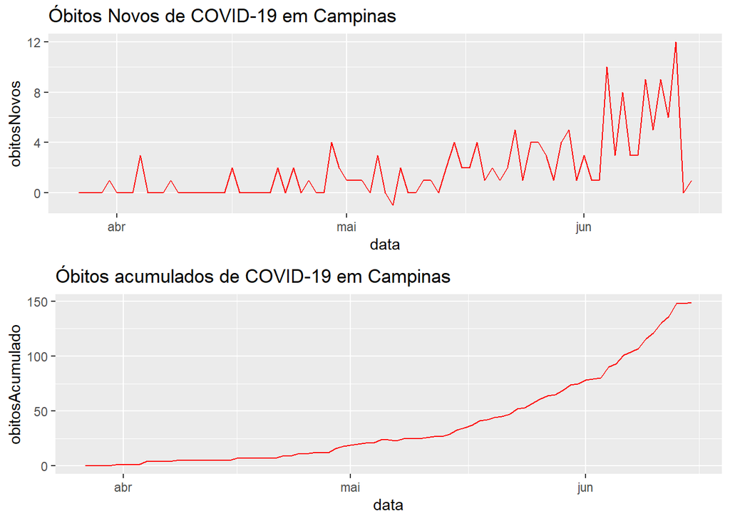

```r
newdeathscps=ggplot(Campinas, aes(data, obitosNovos)) +
  geom_line(color="red") + labs(title="Óbitos Novos de COVID-19 em Campinas")
alldeathscps=ggplot(Campinas, aes(data, obitosAcumulado)) +
  geom_line(color="red") + labs(title="Óbitos acumulados de COVID-19 em Campinas")
grid.arrange(newdeathscps,alldeathscps, ncol=1)
```

Após isso, resolvi analisar os casos e óbitos no estado de São Paulo(SP) de uma maneira geral, e pode-se observar que o número de casos cresce de uma maneira semelhante ao número de óbitos no estado

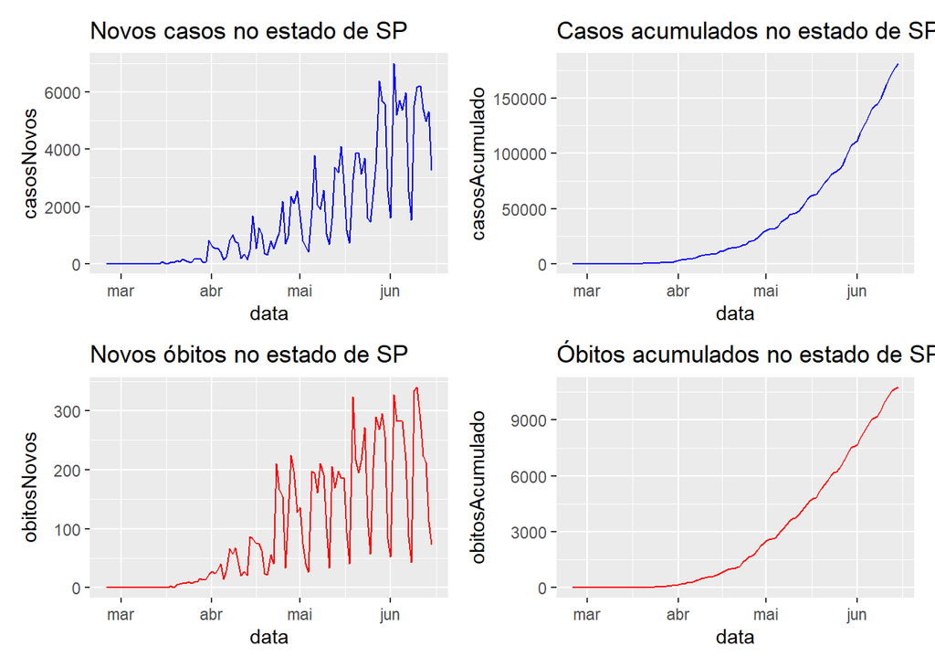

```r
estado_SP=corona %>%
  filter(!is.na(estado), is.na(codmun), estado=="SP")

newcasesSP=ggplot(estado_SP, aes(x = data, y = casosNovos)) +
  geom_line(color="blue") + labs(title = "Novos casos no estado de SP")
newdeathsSP=ggplot(estado_SP, aes(data, obitosNovos)) +
  geom_line(color="red")  + labs(title = "Novos óbitos no estado de SP")
deathsAcSP=ggplot(estado_SP, aes(data, obitosAcumulado)) +
  geom_line(color="red")  + labs(title = "Óbitos acumulados no estado de SP")
acumuladoSP=ggplot(estado_SP, aes(data, casosAcumulado)) +
  geom_line(color="blue") + labs(title = "Casos acumulados no estado de SP")

newcasesSP + acumuladoSP + newdeathsSP + deathsAcSP
```

Após a análise do estado de São Paulo, fiquei curioso em saber como está o crescimento dos casos e óbitos nos estados vizinhos de São Paulo, no caso Minas Gerais(MG) e Rio de Janeiro(RJ). E foi visto que mesmo com o Rio de Janeiro ter muitos mais casos que Minas Gerais, ambos estão com uma curva de crescimento parecida no acumulo de casos e óbitos

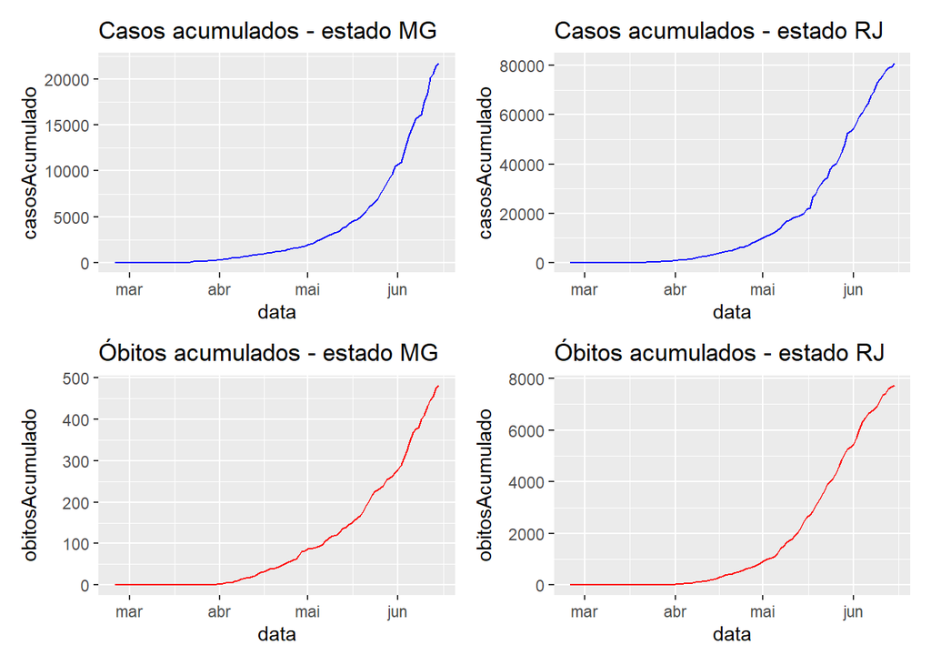

```r
estado_MG=corona %>%
  filter(!is.na(estado), is.na(codmun), estado=="MG")
estado_RJ=corona %>%
  filter(!is.na(estado), is.na(codmun), estado=="RJ")

deathsAcMG=ggplot(estado_MG, aes(data, obitosAcumulado)) +
  geom_line(color="red")  + labs(title = "Óbitos acumulados - estado MG")
acumuladoMG=ggplot(estado_MG, aes(data, casosAcumulado)) +
  geom_line(color="blue") + labs(title = "Casos acumulados - estado MG")
deathsAcRJ=ggplot(estado_RJ, aes(data, obitosAcumulado)) +
  geom_line(color="red")  + labs(title = "Óbitos acumulados - estado RJ")
acumuladoRJ=ggplot(estado_RJ, aes(data, casosAcumulado)) +
  geom_line(color="blue") + labs(title = "Casos acumulados - estado RJ")

acumuladoMG + acumuladoRJ + deathsAcMG + deathsAcRJ
```

E analisando os novos casos em ambos estados

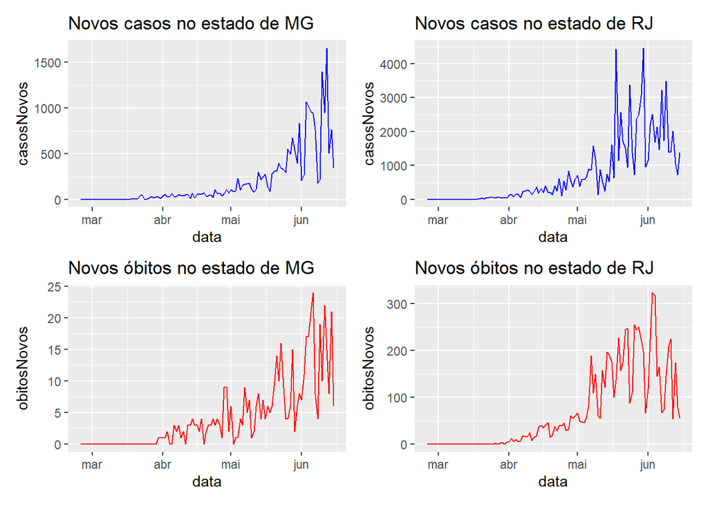

```r
newcasesMG=ggplot(estado_MG, aes(x = data, y = casosNovos)) +
  geom_line(color="blue") + labs(title = "Novos casos no estado de MG")
newdeathsMG=ggplot(estado_MG, aes(data, obitosNovos)) +
  geom_line(color="red")  + labs(title = "Novos óbitos no estado de MG")
newcasesRJ=ggplot(estado_RJ, aes(x = data, y = casosNovos)) +
  geom_line(color="blue") + labs(title = "Novos casos no estado de RJ")
newdeathsRJ=ggplot(estado_RJ, aes(data, obitosNovos)) +
  geom_line(color="red")  + labs(title = "Novos óbitos no estado de RJ")

newcasesMG + newcasesRJ + newdeathsMG + newdeathsRJ
```

Após fazer a analise de estados, resolvi verificar quais são as cidades mais afetadas pelo COVID-19 do estado que moro (São Paulo). E pode notar que são cidades próximas da capital, mas mesmo assim a capital está muito mais afetada comparada as suas cidades vizinhas que também estão sendo mais afetadas nessa pandemia

```r
municipios_SP = municipios <- corona %>%
  filter(!is.na(estado), !is.na(municipio), estado == "SP")

top5cidadesSP <- municipios_SP %>%
  select(municipio, casosNovos) %>%
  group_by(municipio) %>%
  summarise(total_casos = sum(casosNovos)) %>%
  arrange(desc(total_casos))

top5cidadesSP <- top_n(top5cidadesSP, 5)
```

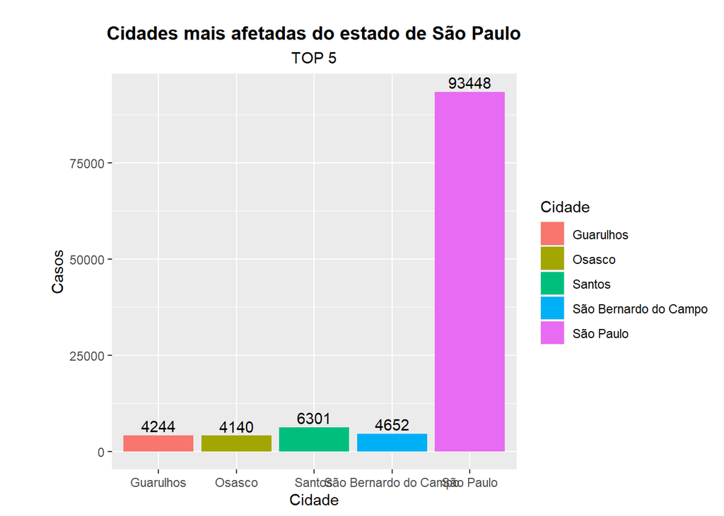

```r
ggplot(top5cidadesSP, mapping = aes(x = municipio, y = total_casos))+
  geom_bar(stat = "identity", aes(fill = municipio))+
  labs(
    title = "Cidades mais afetadas do estado de São Paulo",
    subtitle = "TOP 5",
    x = "Cidade",
    y = "Casos",
    tag = "        "
  )+
  geom_text(aes(label = total_casos, vjust = -0.3) )+
  theme(
    plot.title = element_text(hjust = 0.5, face = "bold"),
    plot.subtitle = element_text(hjust = 0.5)
  )+  scale_fill_discrete(name = "Cidade")
```

Resolvi também analisar quais são as cidades do Brasil que tem os maiores número de óbitos acumulados. E podemos reparar que algumas das capitais dos estados das regiões sudeste, nordeste e norte compoe as 5 cidades com mais óbitos no país, e isso é reflexo da analíse feita anteriormente no crescimento de óbitos nas regiões

```r
municipios = municipios <- corona %>%
  filter(!is.na(estado), !is.na(municipio))

top5mortes <- municipios %>%
  select(municipio, obitosAcumulado) %>%
  group_by(municipio) %>%
  summarise(totalmortes = sum(obitosAcumulado)) %>%
  arrange(desc(totalmortes))

top5mortes <- top_n(top5mortes, 5)
```

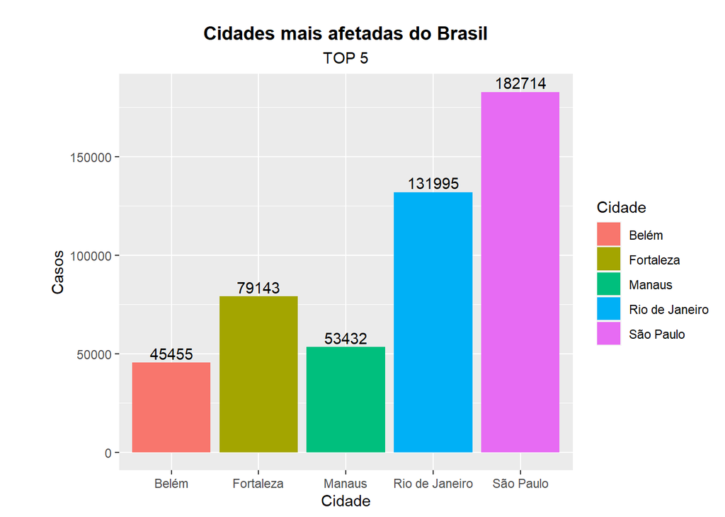

```r
ggplot(top5mortes, mapping = aes(x = municipio, y = totalmortes))+
  geom_bar(stat = "identity", aes(fill = municipio))+
  labs(
    title = "Cidades mais afetadas do Brasil",
    subtitle = "TOP 5",
    x = "Cidade",
    y = "Casos",
    tag = "        "
  )+
  geom_text(aes(label = totalmortes, vjust = -0.3) )+
  theme(
    plot.title = element_text(hjust = 0.5, face = "bold"),
    plot.subtitle = element_text(hjust = 0.5)
  )+  scale_fill_discrete(name = "Cidade")
```

E por fim, a análise de número de óbitos em São Carlos, a cidade onde localiza o campus da UFSCar que estudo

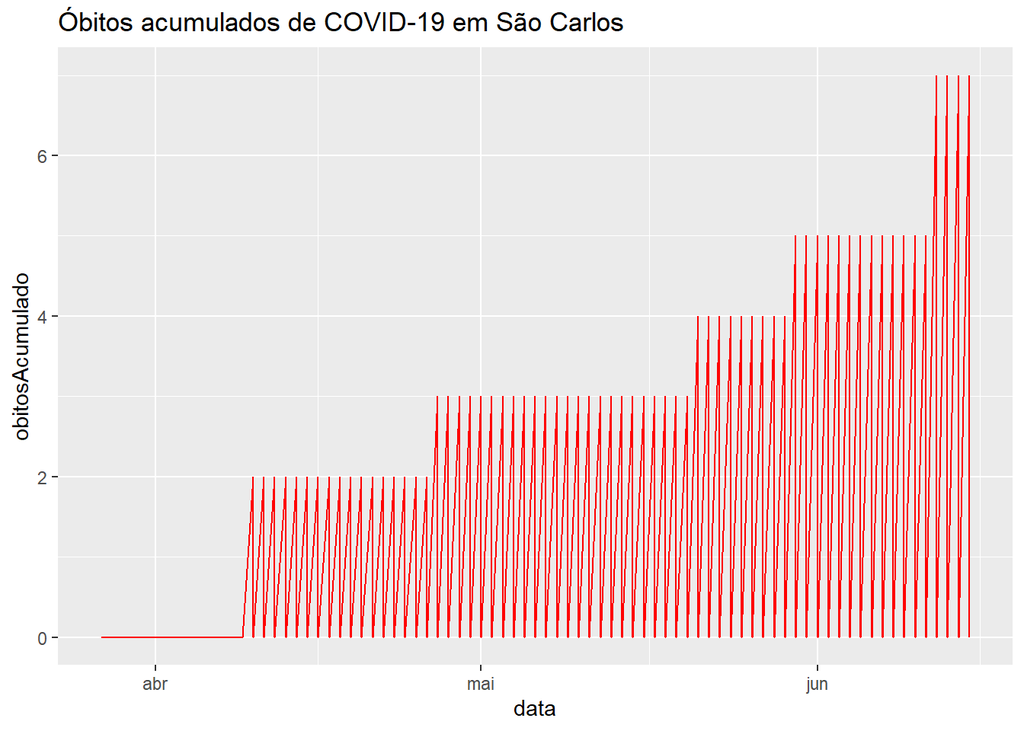

```r
sanca = municipiosSP <- corona %>%
  filter(!is.na(estado), !is.na(municipio), municipio=="São Carlos")
alldeathssanca=ggplot(sanca, aes(data, obitosAcumulado)) +
  geom_line(color="red") + labs(title="Óbitos acumulados de COVID-19 em São Carlos")
alldeathssanca
```